# Trabalho_R

# Pergunta 1 – Classificação das Variáveis

Nesta etapa, procedeu-se à classificação técnica de todas as variáveis presentes na base de dados, identificando a sua natureza e a respetiva escala de medição. Esta classificação é fundamental para selecionar os métodos estatísticos e as representações gráficas mais adequadas.

| Variável | Tipo de Variável | Escala de Medição |
| --- | --- | --- |
| **Name** | Qualitativa Nominal | Nominal |
| **Age** | Quantitativa Contínua | Razão |
| **Gender** | Qualitativa Nominal | Nominal |
| **Blood Type** | Qualitativa Nominal | Nominal |
| **Medical Condition** | Qualitativa Nominal | Nominal |
| **Date of Admission** | Quantitativa Contínua | Intervalo |
| **Doctor / Hospital** | Qualitativa Nominal | Nominal |
| **Insurance Provider** | Qualitativa Nominal | Nominal |
| **Billing Amount** | Quantitativa Contínua | Razão |
| **Room Number** | Qualitativa Nominal | Nominal |
| **Admission Type** | Qualitativa Nominal | Nominal |
| **Discharge Date** | Quantitativa Contínua | Intervalo |
| **Medication** | Qualitativa Nominal | Nominal |
| **Test Results** | Qualitativa Nominal | Nominal |

# Pergunta 2 -Caracterização de variáveis

Vamos usar o R Base para os gráficos da `Age` (Histograma e Boxplot) para evitar que o R tente instalar o `patchwork` ou o `ggplot2` a meio do PDF, o que “suja” o documento.

# 2.1 “Age”

**Classificação:** Quantitativa Contínua (Escala de Razão).

**Justificação:** or ser uma variável quantitativa, utilizam-se medidas de tendência central e dispersão. O histograma permite observar a forma da distribuição, enquanto o boxplot identifica a existência de valores atípicos.

```
   Min. 1st Qu.  Median    Mean 3rd Qu.    Max.
  18.00   34.00   51.00   51.25   68.00   85.00
[1] 19.67971
```

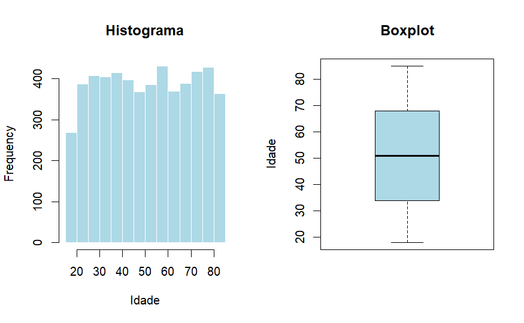

**Exploração**A idade média dos pacientes na amostra é de 51.25 anos. A proximidade entre a média e a mediana, aliada à observação do histograma, sugere uma distribuição relativamente uniforme/simétrica e o boxplot confirma a inexistência de outliers, indicando uma amostra sem casos extremos que influenciem a média.

# 2.2 “Gender”

**Classificação:** Qualitativa Nominal

**Justificação:**Sendo uma variável categórica sem ordem, a análise baseia-se em frequências absolutas e relativas. Utilizou-se um Gráfico de Barras, pois é mais eficaz que o gráfico de setores para comparar proporções de forma rigorosa. Incluiu-se uma linha de referência nos 50% que serve para avaliar o balanço da amostra.

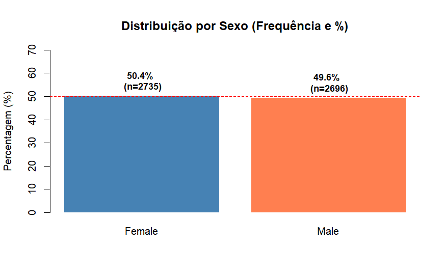

# 2.3 “Blood.Type”

**Classificação:** Variável qualitativa nominal com 8 categorias.

**Justificação:** Utilizou-se um gráfico de barras ordenado de forma decrescente, o que facilita a identificação imediata da “Moda” (o grupo mais frequente).

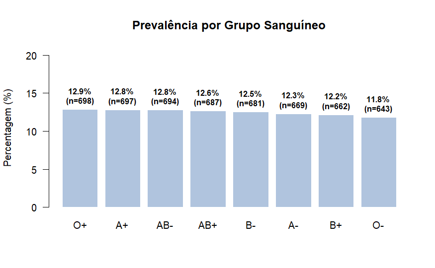

# 2.4 “Medical.Condition”

**Classificação:** Qualitativa Nominal

**Justificação:**Para a variável Medical.Condition, optou-se por um gráfico de barras horizontal. Esta escolha permite uma leitura clara das patologias, evitando a sobreposição de texto, e facilita a comparação da carga de doença entre as diferentes categorias.

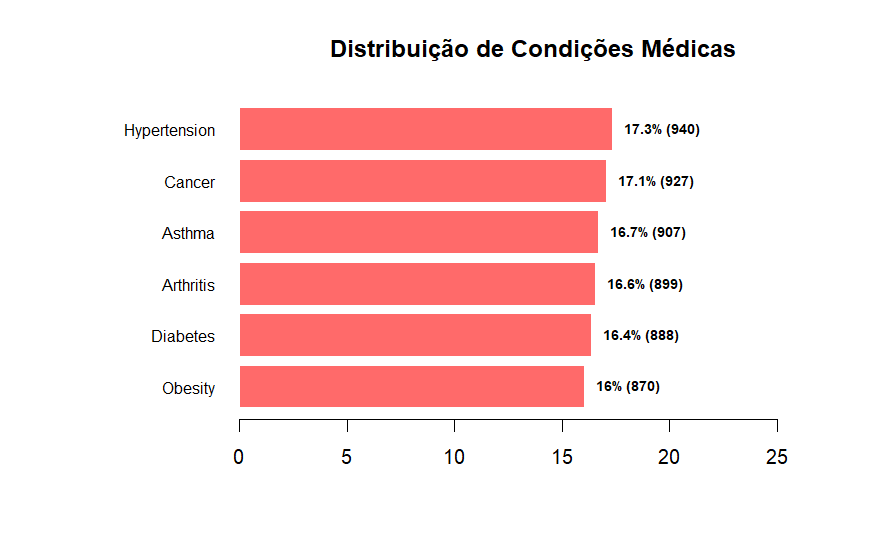